# ETO5513 Project Proposal

Jane Nguyen

2023-06-04

### **Introduction**

As technology rapidly develops around the world, the Internet is is an indispensable factor in the majority of people’s daily lives as it has created a multitude of opportunities and revolutionised the way we learn, work and communicate. Although most of us use the Internet regularly, it is important to recognise that only 60% of the world’s population is present online in 2020.

This report explores the collected data related to the global population’s exposure to the Internet. The collected data are analysed to gain valuable insights into factors that may contribute to the technological discrepancies; these may be due to socioeconomic factors, geographical regions or political agendas.

Research Questions:  
- What are the factors that contribute and have effects on the region’s/country’s Internet usage?  
- Did COVID-19 affect the world’s Internet usage and digital connectivity?

### **Data Set Introduction**

The following report contains 3 different data sets collected from [Our World in Data - Internet](https://ourworldindata.org/internet) (Our World in Data, n.d.). The first data set explores the Number of Internet Users around the world, the second data set provides information on the proportion of individuals using the Internet and the last set focuses on the number of landline Internet subscriptions.

**Data Set 1** contains variables: ‘Entity’, ‘Code’, ‘Year’ and ‘Number of Internet Users’

| Variables |
| --- |
| Entity |
| Code |
| Year |
| Number.of.Internet.users |

**Data Set 2** contains variables: ‘Entity’, ‘Code’, ‘Year’ and ‘Individuals using the Internet (% of population)’

| Variables |
| --- |
| Entity |
| Code |
| Year |
| Individuals.using.the.Internet….of.population. |

**Data Set 3** contains variables: ‘Entity’, ‘Code’, ‘Year’ and ‘Fixed Broadband Subscriptions’

| Variables |
| --- |
| Entity |
| Code |
| Year |
| Fixed.broadband.subscriptions |

### **Data Set Description**

**Data Set 1** contains 25,516 total data points, 6,379 observations and is 205,432 in bytes size. It overall has 4 variables: 2 of them are Character variables (‘Entity’ and ‘Code’), 1 is an Integer variable (‘Year’) and 1 is a Numeric variable (‘Number of Internet Users’).

```
## The byte size in Data Set 1 is: 205432
```

```
## The total number of data points in Data Set 1 is: 25516
##
```

```
## 'data.frame':    6379 obs. of  4 variables:
##  $ Entity                  : chr  "Afghanistan" "Afghanistan" "Afghanistan" "Afghanistan" ...
##  $ Code                    : chr  "AFG" "AFG" "AFG" "AFG" ...
##  $ Year                    : int  1990 1991 1992 1993 1994 1995 2001 2002 2003 2004 ...
##  $ Number.of.Internet.users: num  0 0 0 0 0 ...
```

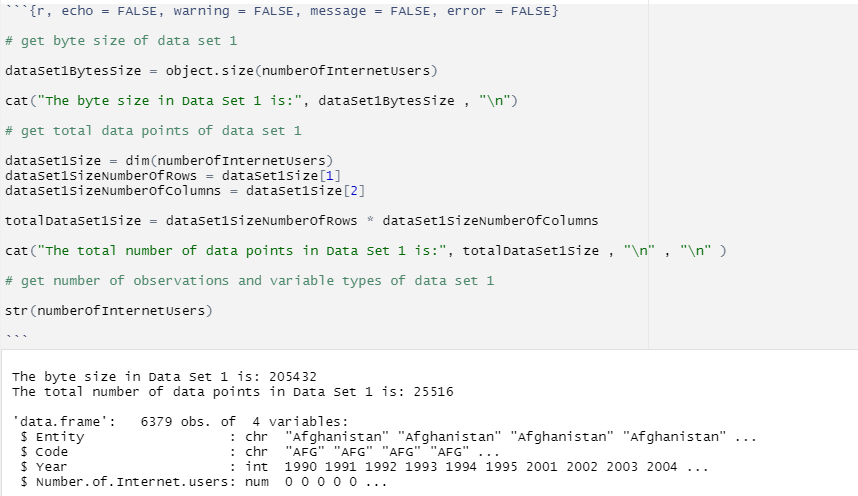

**Data Set 2** contains 26,132 total data points, 6,533 observations and is 210,248 in bytes size. It overall has 4 variables: 2 of them are Character variables (‘Entity’ and ‘Code’), 1 is an Integer variable (‘Year’) and 1 is a Numeric variable (‘Individuals using the Internet (% of population)’).

```
## The byte size in Data Set 2 is: 210248
```

```
## The total number of data points in Data Set 2 is: 26132
##
```

```
## 'data.frame':    6533 obs. of  4 variables:
##  $ Entity                                          : chr  "Afghanistan" "Afghanistan" "Afghanistan" "Afghanistan" ...
##  $ Code                                            : chr  "AFG" "AFG" "AFG" "AFG" ...
##  $ Year                                            : int  1990 1991 1992 1993 1994 1995 2001 2002 2003 2004 ...
##  $ Individuals.using.the.Internet....of.population.: num  0 0 0 0 0 ...
```

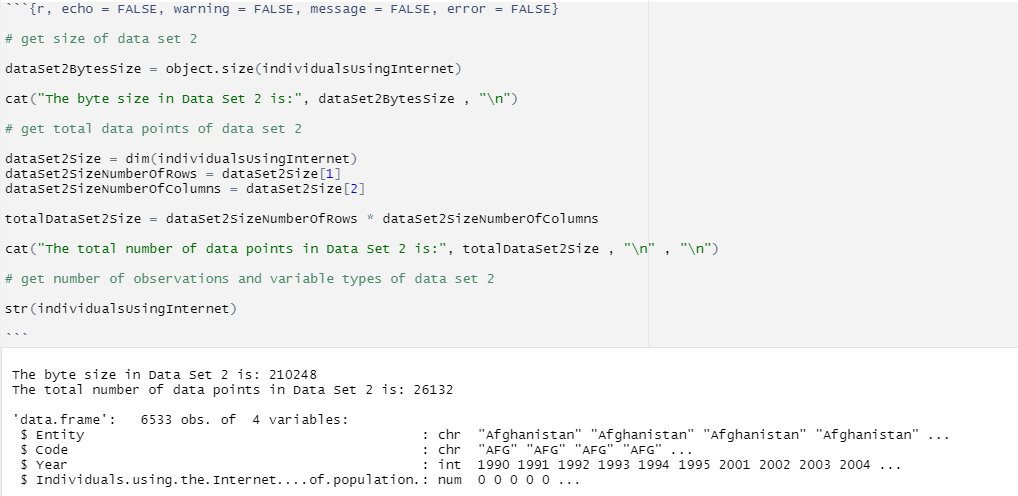

**Data Set 3** contains 15,576 total data points, 3,894 observations and is 135,568 in bytes size. It overall has 4 variables: 2 of them are Character variables (‘Entity’ and ‘Code’), 1 is an Integer variable (‘Year’) and 1 is a Numeric variable (‘Fixed Broadband Subscriptions’).

```
## The byte size in Data Set 3 is: 135568
```

```
## The total number of data points in Data Set 3 is: 15576
##
```

```
## 'data.frame':    3894 obs. of  4 variables:
##  $ Entity                       : chr  "Afghanistan" "Afghanistan" "Afghanistan" "Afghanistan" ...
##  $ Code                         : chr  "AFG" "AFG" "AFG" "AFG" ...
##  $ Year                         : int  2004 2005 2006 2007 2008 2009 2010 2012 2013 2014 ...
##  $ Fixed.broadband.subscriptions: num  200 220 500 500 500 1000 1500 1500 1500 1500 ...
```

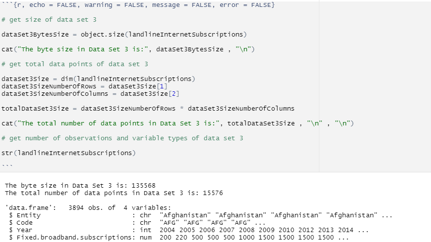

### **Data Summary**

#### Table 1 - Data Set 1

| Statistics | 1990 | 2000 | 2010 | 2020 |
| --- | --- | --- | --- | --- |
| Min. | 0.00 | 0.00 | 0.0 | 48060 |
| 1st Qu. | 0.00 | 10889.25 | 157202.5 | 2071012 |
| Median | 0.00 | 51873.00 | 1032527.0 | 7432437 |
| Mean | 47603.48 | 7693745.57 | 37540231.1 | 112274394 |
| 3rd Qu. | 0.00 | 813034.50 | 6388889.5 | 30862724 |
| Max. | 2617438.00 | 414012675.00 | 2021152970.0 | 4699886462 |

**Table 1** provides the summary data for the years 1990, 2000, 2010 and 2020 based on the Number of Internet Users around the world.

The Minimum row presents the number of Internet users was 0 for 1990, 2000, and 2010. However in 2020, there was a significant increase showcasing a Minimum of 48,060 Internet users. This jump suggests a substantial growth in Internet users between 2010 and 2020, indicating the expansion and adoption of Internet.

#### Table 2 - Data Set 3

| Statistics | 2000 | 2005 | 2010 | 2015 | 2020 |
| --- | --- | --- | --- | --- | --- |
| Min. | 4.0 | 0.0 | 0.00 | 117 | 0.0 |
| 1st Qu. | 2393.5 | 2138.0 | 9183.75 | 19000 | 32000.0 |
| Median | 30077.0 | 21216.0 | 102323.50 | 233234 | 431238.5 |
| Mean | 945910.7 | 5591242.2 | 12554108.46 | 20373463 | 30787353.8 |
| 3rd Qu. | 195075.8 | 579543.5 | 1671464.75 | 2589713 | 3460056.5 |
| Max. | 15733382.0 | 219835680.0 | 531768672.00 | 840118976 | 1229181696.0 |

**Table 2** presents the summary data for the years 2000, 2005, 2010, 2015 and 2020 based on the number of Landline Internet Subscriptions globally.

It is interesting to note that the Minimum values decreased between 2000 and 2005 as well as between 2015 and 2020. Similarly, the 25th percentile (1st Quartile) values from 2000 to 2005 also experienced a downward trend. This decline can be attributed to the improvements of Internet infrastructures. These new structures allow for faster access and connection to the Internet, which may have resulted in the decrease of landline Internet subscriptions in these time periods.

### **Visualisations**

#### Figure 1

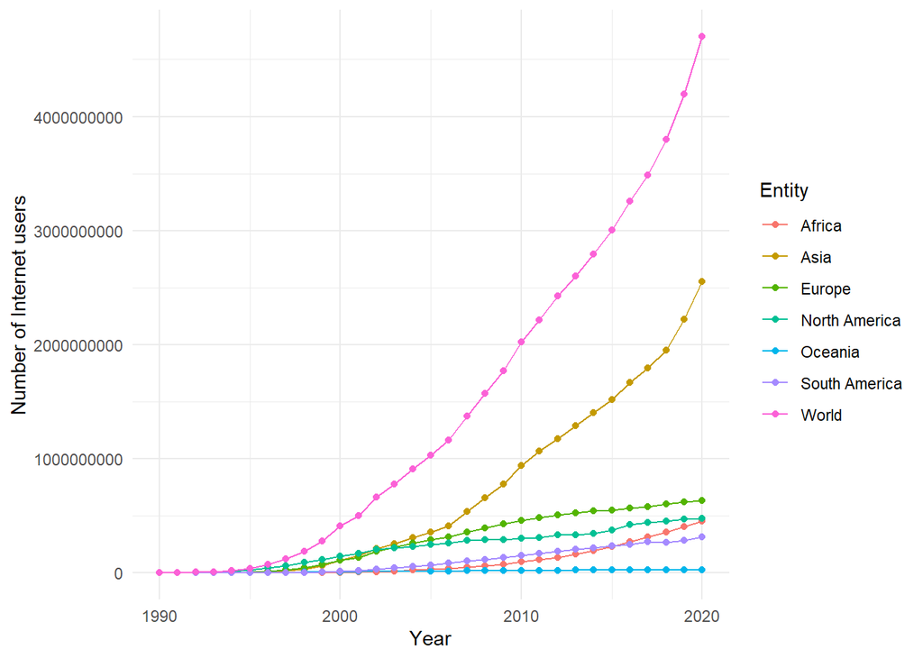

*Figure 1* presents the number of people who have used the Internet in the past 3 months. The variables have been sub-divided into geographical locations to demonstrate a more thorough analysis on the increase of Internet users.

- The variable ‘World’ presents as the highest number of Internet users as it calculates the total globally. The graph shows the region ‘Asia’ with the highest number of Internet users. This is consistent from the year 2002 as ‘Asia’ surpassed the region ‘North America’ in Internet users, with 212.70 million and 205.26 million users respectively. Before 2002, the region ‘North America’ had the leading number of Internet users. Furthermore, in 2003, the geographical region ‘Europe’ also surpassed ‘North America’ with 227.61 million and 218.60 million Internet users respectively.
- In 2020, ‘Asia’ recorded an impressive 2.55 billion Internet users, accounting for 54% of the global total represented by the ‘World’ variable, which stood at 4.70 billion users. This highlights the significant presence of ‘Asia’ in the global Internet landscape. Moreover, since 2006, ‘Asia’ has experienced rapid growth in Internet users, surpassing the growth rates of other geographical regions.
- The region ‘Oceania’ shows the lowest growth in Internet users compared to other regions. This could be attributed to the smaller populations of Pacific islands within this region, which may limit the overall growth of Internet usage.
- It is worth noting a significant surge in Internet users from 2019 to 2020, particularly when considering the ‘World’ entity. This notable increase can be attributed to various factors, with the COVID-19 pandemic playing a significant role. The global outbreak prompted many countries to implement work from home measures and social distancing protocols, leading to a substantial rise in Internet usage.

#### Figure 2

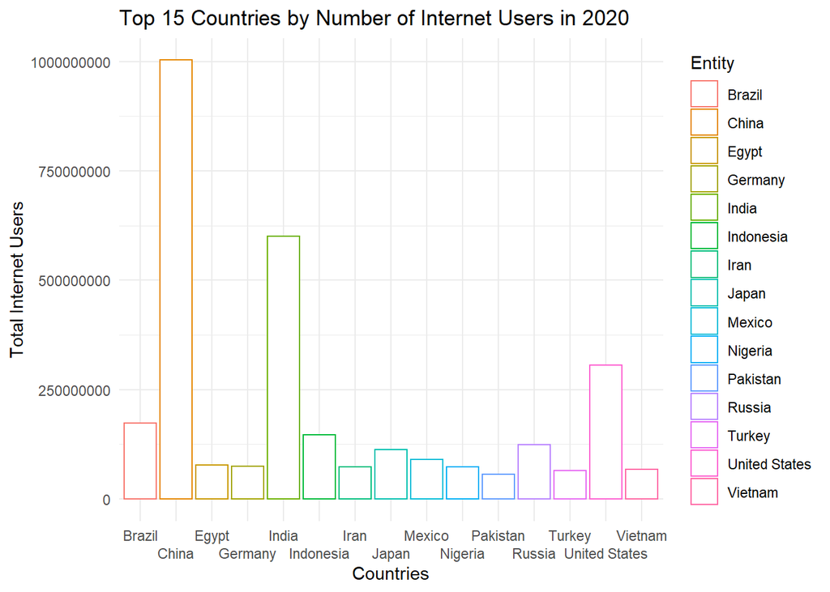

*Figure 2* showcases the top 15 countries with the highest number of Internet users in 2020.

- China takes the lead, followed by India in second place and the United States in third. This ranking highlights the influence of population density on the number of Internet users, with highly populous countries such as China and India claiming the top positions.
- China’s position at the top of the list can be attributed to its enormous population, which naturally leads to a larger user base. Similarly, India’s second-place ranking is also a reflection of its substantial population size. The United States is known for its technological advancements and widespread Internet accessibility. They secured a prominent position in the ranking despite having a smaller population compared to China and India.
- The data shows the significance of population size when examining the number of Internet users in each country. Countries with larger populations are more likely to have a higher number of Internet users as the potential user base is larger.

#### Figure 3

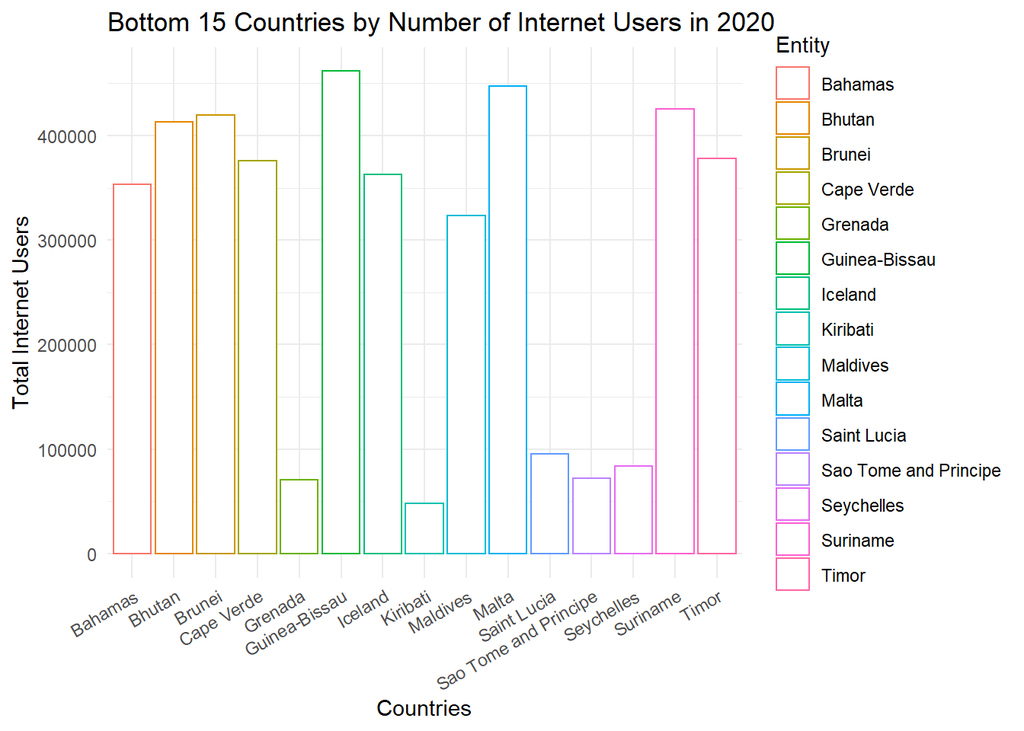

The bar graph displays the bottom 15 countries in terms of Internet usage in 2020. These countries appear in this ranking due to their smaller population sizes, which directly impacts the overall frequency of Internet usage.

- The graph highlights the correlation between population size and Internet usage, as countries with smaller populations tend to have lower rates of Internet adoption. Consequently, these countries find themselves in the lower positions of the ranking.

#### Figure 4

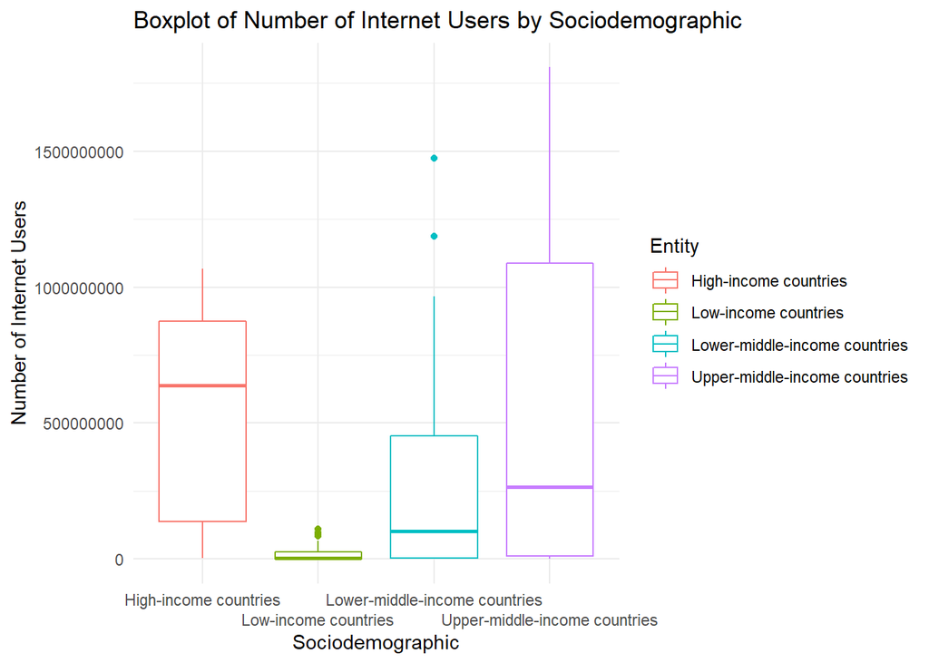

*Figure 4* consists of four boxplots, representing different socioeconomic backgrounds: High Income Countries, Low Income Countries, Lower Middle Income Countries, and Upper Middle Income Countries.

- The Upper Middle Income Countries exhibits the largest range in terms of the socioeconomic variables being analysed. This indicates a wider variation within this group, containing countries with diverse economic conditions and developments.
- The boxplot for High Income Countries reveals the highest median among the four groups. This suggests that, on average, countries classified as High Income have higher values for the socioeconomic variables compared to the other categories.

#### Figure 5

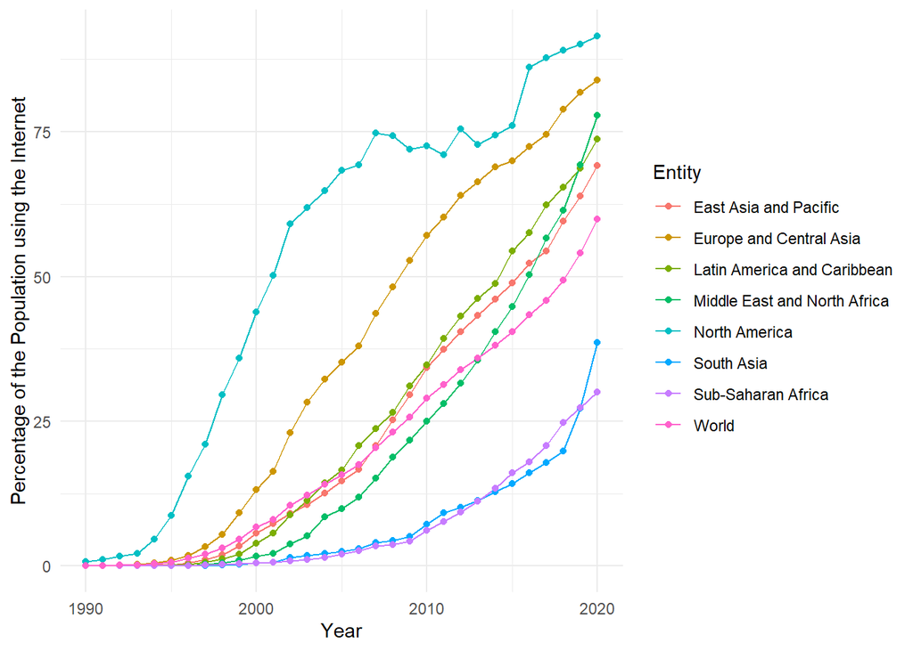

The line chart illustrates the percentage of population engaging in Internet usage within the past 3 months. The ‘World’ entity serves as the reference point for the standard percentage of Internet usage. From the chart, we can observe that entities such as ‘North America’, ‘Europe and Central Asia’, ‘Middle East and North Africa’, ‘Latin America and Caribbean’, and ‘East Asia and Pacific’ surpass the ‘World’ standard in terms of Internet usage.

#### Figure 6

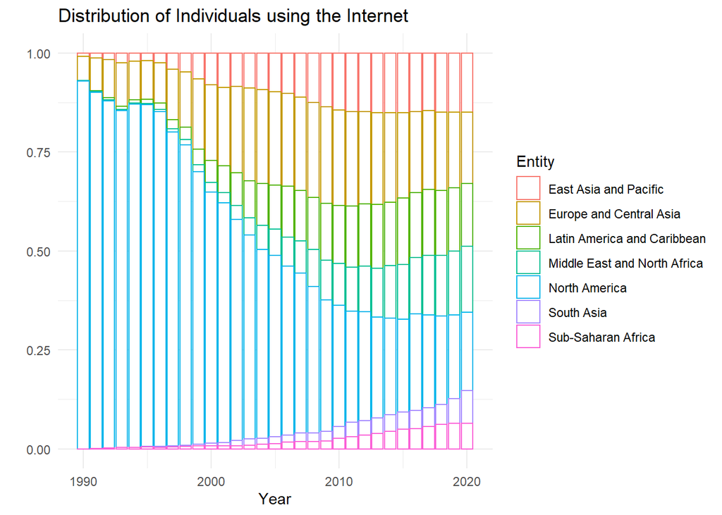

The stacked bar chart provides a visual presentation of the distribution of individuals using the Internet across different regions. This chart enables us to clearly observe the transition of Internet adoption in these regions over the years.

- In 1990, ‘North America’ emerges as the dominant region in terms of Internet usage. However overtime, the distribution gradually shifts towards a more balanced allocation across regions.
- The chart’s depiction of the changing distribution of Internet adoption offers valuable insights into the global landscape of connectivity. It highlights the progress made by various regions in embracing and incorporating Internet technologies into their societies.

#### Figure 7

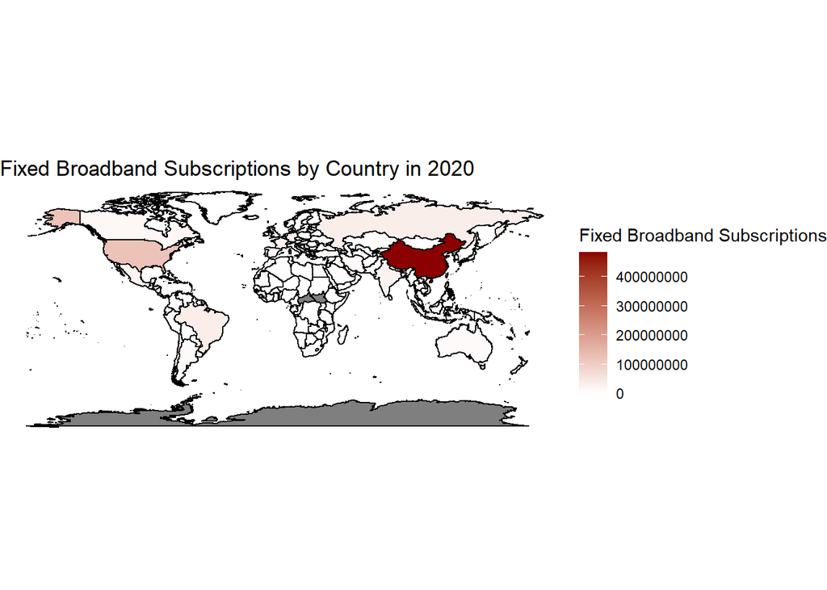

The heat map provides a visual representation of the global distribution of fixed broadband subscriptions among countries.

- In 2020, China emerges as the clear leader, sitting at 483.55 million fixed broadband subscriptions. This remarkable figure indicates the country’s dominance in terms of broadband adoption, with no other country coming close to matching its number of subscriptions.
- While several countries such as the United States (121.18 million), Brazil (36.34 million), Germany (36.22 million) and Russia (33.89 million) exhibit substantial subscription numbers, they are still considerably low when compared to China’s vast number of subscriptions.

#### Figure 8

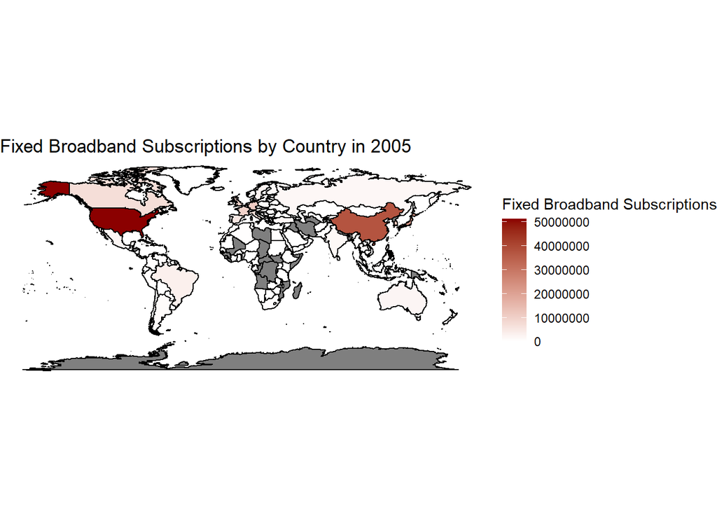

*Figure 8* showcases the global fixed broadband subscription in the year 2005, highlighting the number of subscriptions by country.

- In 2005, the United States claims the top position with the highest number of fixed broadband subscriptions, reaching 51.16 million subscriptions. China also holds a significant position in the ranking, with 37.35 million subscriptions.
- This data reflects the prominence of the United States and China in terms of fixed broadband adoption in 2005. The United States, known for its technological advancements and infrastructure, demonstrates a strong presence of Internet subscriptions. Similarly, China’s growing economy and population contribute to its high number of fixed broadband subscriptions during that period.

#### Figure 9

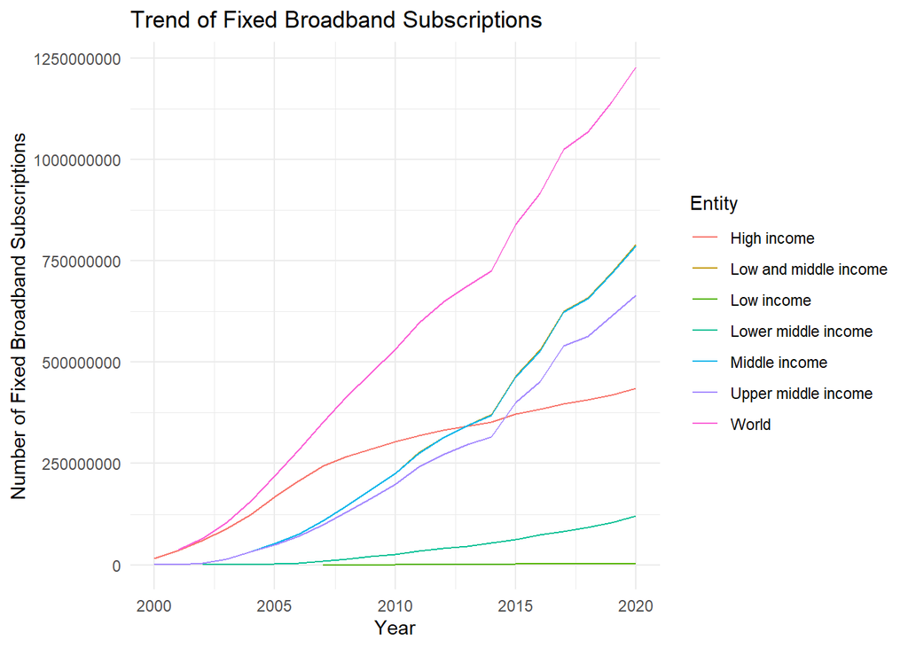

The line chart presents the distribution of fixed broadband subscriptions across different sociodemographic categories, including High Income, Low and Middle Income, Low Income, Lower Middle Income, Middle Income, and Upper Middle Income.

#### Figure 10

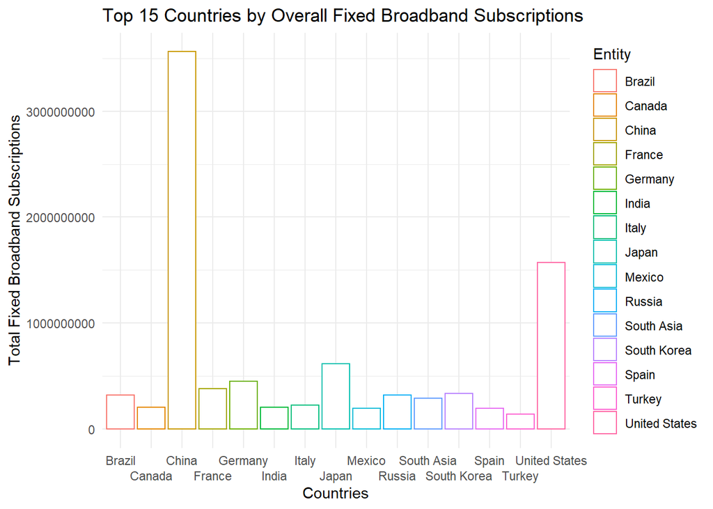

*Figure 10* showcases the top 15 countries with the highest fixed broadband subscriptions.

- With its vast population, China leads the list with the highest number of fixed broadband subscriptions. The United States and Japan, renowned for their technological advancements and innovation-driven societies, also demonstrate a strong presence in fixed broadband subscriptions.

#### Figure 11

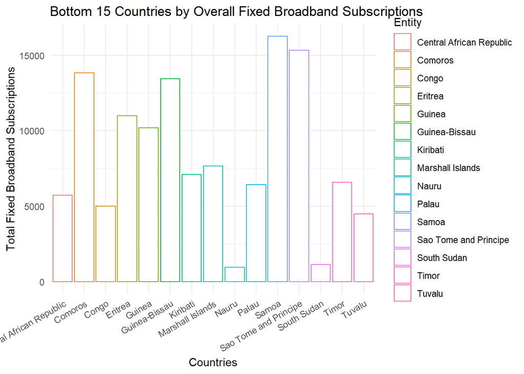

The bar chart presented in *Figure 11* presents the lowest 15 countries in terms of fixed broadband subscription.

- These countries exhibit a major contrast when compared to the previous chart, primarily due to their limited number of subscriptions, which is below 20,000. This disparity can be attributed to several factors, including the overall economic prosperity and the countries’ capacity to provide widespread access to fixed broadband services.
- A significant portion of the countries shown in this graph are located in Sub-Saharan Africa. Despite the relatively large populations of countries like the Central African Republic, Congo, and South Sudan, their limited fixed broadband subscription numbers can be attributed to factors such as economic stability and political circumstances, which impact their ability to provide widespread access to broadband services.
- Additionally, the presence of small Pacific islands like Nauru, Tuvalu, Palau, and others also affects their subscription rates due to their limited population size and geographical constraints.

#### Figure 12

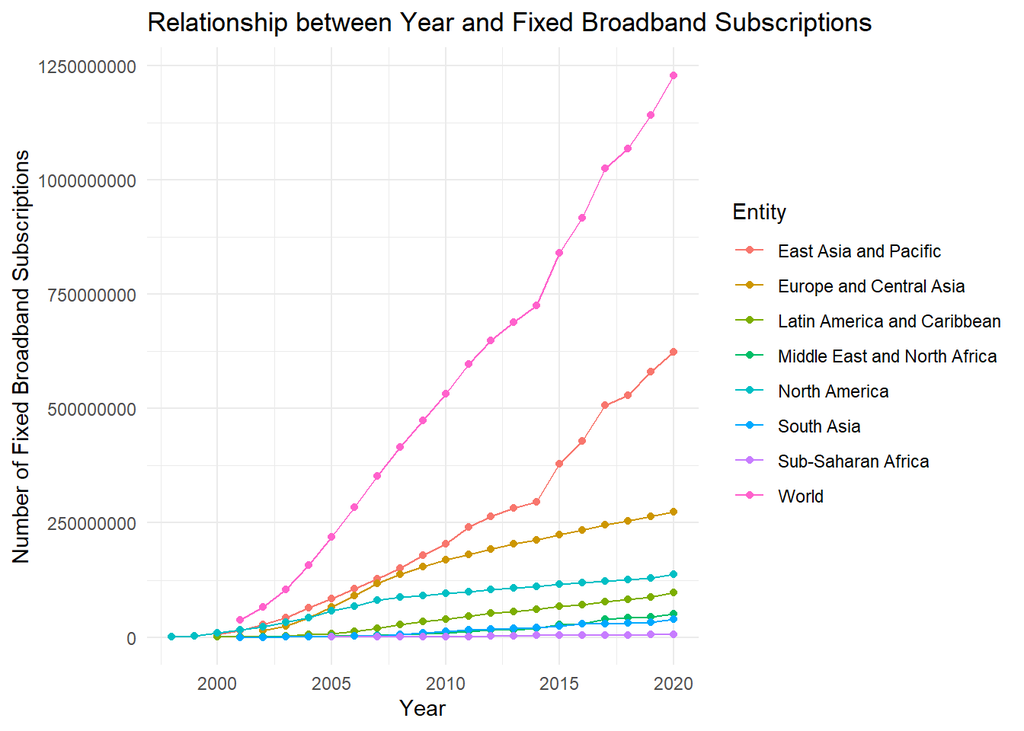

The line chart illustrates the growth of fixed broadband subscriptions across regions, revealing that Sub-Saharan Africa experiences comparatively lower growth.

- This discrepancy can be attributed to the region’s overall economic conditions, impacting its ability to invest in and develop broadband infrastructure.

### **Conclusion**

This report has explored various aspects of Internet usage and connectivity across different regions and socioeconomic backgrounds.The data reveals disparities in Internet adoption based on factors such as geographic location, population size, and socioeconomic conditions. While some regions and countries exhibit high rates of Internet usage, there are still many countries that have limited access to the Internet.

The analysis shows the influence of factors such as population size and economic development on Internet usage. Countries with larger populations tend to have higher numbers of Internet users, while regions with stronger economies demonstrate higher levels of connectivity.

COVID-19 also had a big impact on Internet usage, with a noticeable increase seen in several areas. Due to the pandemic, people are able to access the Internet more frequently because of remote work and online education.

The report highlights the importance of understanding and addressing the disparities in Internet usage across regions and socioeconomic backgrounds.

### **Reference**

H, Ritchie., E, Mathieu., M, Roser., and E, Ortiz-Ospina. (2023). *Internet*. OurWorldInData. https://ourworldindata.org/internet